# Module_6_Assignment

### Module 6. Perform PCA for Dimensions 1-5 of Chile's Tourism Regions

In order to help Chilean government improve the tourism industry in the country, 5 regions of Chile under the 5 dimensions should be evaluated and generated some meaninful insights and recommendations.

#### Import useful libraries

```python
import pandas as pd
import numpy as np
import matplotlib.pyplot as plt
import seaborn as sns
from sklearn.decomposition import PCA
from sklearn.impute import SimpleImputer
from sklearn.preprocessing import StandardScaler
```

#### Clean the data and transform the data format for further analysis

```python
# Set additional parameters for charts and tables

# Remove column display limits
pd.set_option('display.max_columns', None)
# pd.set_option('display.height', None)
pd.set_option('display.max_rows', None)
# pd.set_option('display.width', None)
plt.rcParams['figure.figsize'] = [15, 10]
sns.set_style("white")
```

```python
# Read data in csv format, using encoding, and read the third row as column names
chile_data = pd.read_excel('Tourism Chile D1 - D5_updated1019.xlsx', encoding = 'ISO-8859-1', header = 3)
```

```python
# Print
chile_data.head()
```

|  | Unnamed: 0 | N° | VARIABLE | CULTURAL EVENTS SCHEDULED THROUGHOUT THE YEAR | NUMBER OF CULTURAL CENTERS | WORLD CULTURAL HERITAGE SITES | NUMBER OF ARCHEOLOGICAL SITES | NATIONAL MONUMENTS | MUSEUMS | % OF POPULATION THAT ATTENDS MUSEUMS | THEATERS | NUMBER OF THEATER PLAYS PER YEAR | LIBRARIES | GALERIES | % OF POPULATION ASSOCIATED TO AN INDIGENOUS GROUP | NUMBER OF EXHIBITS | ARTISTIC EVENTS (MUSIC, DANCE AND FOLKLOR, THEATRE, ETC) PER YEAR | MAJOR SPORTS EVENTS PER YEAR | OBSERVATORIES, ZOOS, AQUARIUMS, BOTANICAL GARDENS | ARTWORK SITES | POPULAR ARCHITECTURE SITES | HISTORICAL SITES | LOCAL MARKETS | CULTURAL SITES LEVEL III (INTERNATIONAL) | CULTURA SITES LEVEL II (NATIONAL) | CULTURAL SITES LEVEL I (LOCAL) | HERITAGE ARCHITECTURAL HOUSES | % OF LAND THAT CORRESPONDS TO FORESTS | NATIONAL PROTECTED SITES (%) | … |
| --- | --- | --- | --- | --- | --- | --- | --- | --- | --- | --- | --- | --- | --- | --- | --- | --- | --- | --- | --- | --- | --- | --- | --- | --- | --- | --- | --- | --- | --- | --- |
| 0 | NaN | XV | Arica y Parinacota | 31.0 | 2 | 0 | 30 | 28 | 4 | 22.1 | 2 | 105 | 12 | 2 | 25.4 | 1 | 0 | 0 | 0 | 4 | 32 | 4 | 3 | 9 | 32 | 7 | 59 | - | 21.9 | … |
| 1 | NaN | I | Tarapacá | 0.0 | 5 | 1 | 13 | 73 | 5 | 20.8 | 2 | 178 | 12 | 1 | 12.6 | 1 | 0 | 0 | 0 | 0 | 34 | 10 | 1 | 6 | 34 | 12 | 0 | 0.17288 | 9.1 | … |
| 2 | NaN | II | Antofagasta | 1.0 | 9 | 0 | 28 | 81 | 16 | 27.4 | 8 | 203 | 15 | 2 | 5.7 | 2 | 1 | 0 | 3 | 1 | 24 | 37 | 0 | 4 | 31 | 26 | 63 | - | 2.8 | … |
| 3 | NaN | III | Atacama | 8.0 | 10 | 0 | 8 | 35 | 7 | 20.0 | 0 | 144 | 12 | 0 | 7.5 | 0 | 0 | 0 | 0 | 0 | 18 | 5 | 0 | 2 | 29 | 7 | 33 | - | 2.0 | … |
| 4 | NaN | IV | Coquimbo | 23.0 | 7 | 0 | 2 | 52 | 7 | 18.3 | 4 | 80 | 22 | 2 | 1.7 | 0 | 1 | 0 | 7 | 1 | 69 | 2 | 1 | 0 | 29 | 27 | 97 | 0.77048 | 0.4 | … |

```python
# Remove first 2 columns
chile_data.drop(chile_data.iloc[:, 0:2], inplace = True, axis = 1)
```

```python
# Print the whole dataframe
chile_data
# As you can see, we cleaned almost everything, but the last row with the aggregated information must be removed too
```

|  | VARIABLE | CULTURAL EVENTS SCHEDULED THROUGHOUT THE YEAR | NUMBER OF CULTURAL CENTERS | WORLD CULTURAL HERITAGE SITES | NUMBER OF ARCHEOLOGICAL SITES | NATIONAL MONUMENTS | MUSEUMS | % OF POPULATION THAT ATTENDS MUSEUMS | THEATERS | NUMBER OF THEATER PLAYS PER YEAR | LIBRARIES | GALERIES | % OF POPULATION ASSOCIATED TO AN INDIGENOUS GROUP | NUMBER OF EXHIBITS | ARTISTIC EVENTS (MUSIC, DANCE AND FOLKLOR, THEATRE, ETC) PER YEAR | MAJOR SPORTS EVENTS PER YEAR | OBSERVATORIES, ZOOS, AQUARIUMS, BOTANICAL GARDENS | ARTWORK SITES | POPULAR ARCHITECTURE SITES | HISTORICAL SITES | LOCAL MARKETS | CULTURAL SITES LEVEL III (INTERNATIONAL) | CULTURA SITES LEVEL II (NATIONAL) | CULTURAL SITES LEVEL I (LOCAL) | HERITAGE ARCHITECTURAL HOUSES | % OF LAND THAT CORRESPONDS TO FORESTS | NATIONAL PROTECTED SITES (%) | % LAND THAT CORRESPONDS TO HUMAN SETTLEMENTS | TOXIC WASTE DISPOSAL (TONS/100 hab.) | … |
| --- | --- | --- | --- | --- | --- | --- | --- | --- | --- | --- | --- | --- | --- | --- | --- | --- | --- | --- | --- | --- | --- | --- | --- | --- | --- | --- | --- | --- | --- | --- |
| 0 | Arica y Parinacota | 31.0 | 2 | 0 | 30 | 28 | 4 | 22.1 | 2 | 105 | 12 | 2 | 25.4 | 1 | 0 | 0 | 0 | 4 | 32 | 4 | 3 | 9 | 32 | 7 | 59 | - | 21.9 | 0.458002 | 58.001835 | … |
| 1 | Tarapacá | 0.0 | 5 | 1 | 13 | 73 | 5 | 20.8 | 2 | 178 | 12 | 1 | 12.6 | 1 | 0 | 0 | 0 | 0 | 34 | 10 | 1 | 6 | 34 | 12 | 0 | 0.17288 | 9.1 | 0.027992 | 76.025528 | … |
| 2 | Antofagasta | 1.0 | 9 | 0 | 28 | 81 | 16 | 27.4 | 8 | 203 | 15 | 2 | 5.7 | 2 | 1 | 0 | 3 | 1 | 24 | 37 | 0 | 4 | 31 | 26 | 63 | - | 2.8 | 0.028164 | 39.558771 | … |
| 3 | Atacama | 8.0 | 10 | 0 | 8 | 35 | 7 | 20.0 | 0 | 144 | 12 | 0 | 7.5 | 0 | 0 | 0 | 0 | 0 | 18 | 5 | 0 | 2 | 29 | 7 | 33 | - | 2.0 | 0.018915 | 40.763793 | … |
| 4 | Coquimbo | 23.0 | 7 | 0 | 2 | 52 | 7 | 18.3 | 4 | 80 | 22 | 2 | 1.7 | 0 | 1 | 0 | 7 | 1 | 69 | 2 | 1 | 0 | 29 | 27 | 97 | 0.77048 | 0.4 | 0.354952 | 25.445036 | … |
| 5 | Valparaíso | 14.0 | 37 | 2 | 24 | 161 | 12 | 25.7 | 7 | 322 | 56 | 7 | 3.2 | 3 | 3 | 1 | 4 | 2 | 48 | 21 | 4 | 46 | 90 | 36 | 720 | 6.48788 | 2.7 | 2.109291 | 38.456163 | … |
| 6 | Metropolitana | 4.0 | 56 | 0 | 1 | 404 | 35 | 22.5 | 70 | 6558 | 127 | 25 | 4.1 | 30 | 0 | 0 | 3 | 2 | 5 | 9 | 4 | 4 | 85 | 112 | 274 | 6.85241 | 0.9 | 7.246534 | 47.026844 | … |
| 7 | O'Higgins | 32.0 | 13 | 1 | 9 | 67 | 6 | 21.9 | 13 | 251 | 36 | 0 | 1.9 | 1 | 7 | 2 | 3 | 16 | 29 | 3 | 1 | 0 | 28 | 15 | 229 | 11.3085 | 2.8 | 0.920951 | 27.151123 | … |
| 8 | Maule | 29.0 | 17 | 0 | 1 | 54 | 7 | 11.1 | 9 | 657 | 29 | 1 | 1.6 | 1 | 7 | 0 | 0 | 10 | 27 | 4 | 3 | 0 | 37 | 28 | 19 | 12.6985 | 0.6 | 0.411696 | 32.858164 | … |
| 9 | Biobío | 5.0 | 32 | 0 | 0 | 59 | 20 | 18.9 | 12 | 488 | 63 | 7 | 3.9 | 10 | 0 | 0 | 0 | 4 | 13 | 23 | 2 | 0 | 10 | 54 | 135 | 20.7332 | 2.8 | 0.962911 | 31.680761 | … |
| 10 | Araucanía | 18.0 | 13 | 0 | 2 | 96 | 5 | 13.2 | 8 | 179 | 58 | 4 | 30.1 | 0 | 5 | 3 | 0 | 13 | 16 | 6 | 10 | 0 | 12 | 31 | 20 | 29.4361 | 9.6 | 0.430527 | 36.785178 | … |
| 11 | Los Ríos | 3.0 | 9 | 0 | 1 | 33 | 8 | 16.2 | 3 | 94 | 12 | 2 | 16.7 | 2 | 1 | 0 | 1 | 0 | 10 | 5 | 2 | 0 | 10 | 19 | 55 | 46.1093 | 6.9 | 0.312223 | 35.412014 | … |
| 12 | Los Lagos | 1.0 | 24 | 1 | 0 | 64 | 11 | 19.8 | 8 | 272 | 31 | 1 | 20.8 | 2 | 0 | 0 | 0 | 0 | 38 | 3 | 3 | 0 | 57 | 30 | 94 | 56.3222 | 15.9 | 0.181163 | 34.766770 | … |
| 13 | Aysén | 0.0 | 4 | 0 | 2 | 17 | 0 | 14.8 | 0 | 49 | 12 | 0 | 21.8 | 0 | 0 | 0 | 0 | 0 | 24 | 2 | 0 | 1 | 20 | 10 | 0 | 44.3851 | 39.4 | 0.020771 | 43.886897 | … |
| 14 | Magallanes y Antártica | 0.0 | 3 | 0 | 2 | 45 | 6 | 27.7 | 2 | 4 | 14 | 0 | 22.7 | 3 | 0 | 0 | 0 | 2 | 16 | 16 | 0 | 2 | 24 | 11 | 34 | 20.1948 | 57.3 | 0.035407 | 40.575232 | … |
| 15 | NaN | NaN | 241 | 5 | 123 | 1269 | 149 | 300.4 | 148 | 9584 | 511 | 54 | NaN | 56 | 25 | 6 | 21 | 55 | 403 | 150 | 34 | 74 | 528 | 425 | 1832 | 255.471 | 175.1 | 13.519500 | 608.394109 | … |

```python
# Remove the last row with aggregated Total data
chile_data = chile_data[:-1]
```

```python
# Print dimensions
chile_data.shape
```

```
(15, 82)
```

```python
# Rename the first column
chile_data = chile_data.rename(columns={'VARIABLE': 'Region'})
```

```python
# Check NaNs in the dataset
chile_data.isnull().sum(axis = 0)
# Only one NaN (LAND AFFECTED BY WILDFIRES) at the first sight, but it is not exactly true
```

```
Region                                                                       0
CULTURAL EVENTS SCHEDULED THROUGHOUT THE YEAR                                0
NUMBER OF CULTURAL CENTERS                                                   0
WORLD CULTURAL HERITAGE SITES                                                0
NUMBER OF ARCHEOLOGICAL SITES                                                0
NATIONAL MONUMENTS                                                           0
MUSEUMS                                                                      0
% OF POPULATION THAT ATTENDS MUSEUMS                                         0
THEATERS                                                                     0
NUMBER OF THEATER PLAYS PER YEAR                                             0
LIBRARIES                                                                    0
GALERIES                                                                     0
% OF POPULATION ASSOCIATED TO AN INDIGENOUS GROUP                            0
NUMBER OF EXHIBITS                                                           0
ARTISTIC EVENTS (MUSIC, DANCE AND FOLKLOR, THEATRE, ETC) PER YEAR            0
MAJOR SPORTS EVENTS PER YEAR                                                 0
OBSERVATORIES, ZOOS, AQUARIUMS, BOTANICAL GARDENS                            0
ARTWORK SITES                                                                0
POPULAR ARCHITECTURE SITES                                                   0
HISTORICAL SITES                                                             0
LOCAL MARKETS                                                                0
CULTURAL SITES LEVEL III (INTERNATIONAL)                                     0
CULTURA SITES LEVEL II (NATIONAL)                                            0
CULTURAL SITES LEVEL I (LOCAL)                                               0
HERITAGE ARCHITECTURAL HOUSES                                                0
% OF LAND THAT CORRESPONDS TO FORESTS                                        0
NATIONAL PROTECTED SITES (%)                                                 0
% LAND THAT CORRESPONDS TO HUMAN SETTLEMENTS                                 0
TOXIC WASTE DISPOSAL (TONS/100 hab.)                                         0
NUMBER OF ENVIRONMENTAL COMPLAINTS PRESENTED                                 0
ENVIRONMENTAL ISSUES PER MILLION HABITANTS                                   0
NUMBER OF BEACHES AND BEACH RESORTS                                          0
LAND AFFECTED BY WILDFIRES                                                   1
NATURAL PROTECTED SITES LEVEL III (INTERNATIONAL)                            0
NATURAL PROTECTED SITES LEVEL II (NATIONAL)                                  0
RIVERS, LAKES AND WATERFALLS                                                 0
MOUNTAINS, VOLCANOES AND MOUNTAIN SYSTEMS                                    0
GEISERS AND THERMAL CENTERS                                                  0
PIERS AND SEASHORES                                                          0
GLACIERS AND WINTER VACATION LOCATIONS                                       0
```

[output cut: 28 more lines]

```
TOURISM-RELATED INVESTEMENTS (MILLION USD) BY CHAMBER OF COMMERCE MEMBERS    0
TOURISM-RELATED INFRASTRUCTURE INVESTMENT (MILLION USD/YEAR)                 0
NATIONAL TOURISTS ARRIVALS                                                   0
INTERNATIONAL TOURISTS ARRIVALS                                              0
NUMBER OF PEOPLE TRAVELING OUT OF THE COUNTRY                                0
DENSITY OF AIRPORTS                                                          0
DENSITY OF ROADS AND HIGHWAYS                                                0
% OF ROADS THAT ARE HIGHWAYS (FOUR LINES)                                    0
NUMBER OF VEHICLES                                                           0
VISITORS TO PROTECTED SITES                                                  0
NUMBER OF CRUISES THAT ARRIVE PER YEAR                                       0
TOURIST'S ARRIVALS THROUGH BORDER LINES                                      0
SECONDARY ROADS (KMS)                                                        0
NUMBER OF INTERNATIONAL BORDER GATES                                         0
dtype: int64
```

```python
# Types of columns
chile_data.dtypes[0:10]
# When we see each column by type, we can see that not all of them have integers or floats. Some are objects.
# We need to dig into it more
```

```
Region                                            object
CULTURAL EVENTS SCHEDULED THROUGHOUT THE YEAR    float64
NUMBER OF CULTURAL CENTERS                         int64
WORLD CULTURAL HERITAGE SITES                      int64
NUMBER OF ARCHEOLOGICAL SITES                      int64
NATIONAL MONUMENTS                                 int64
MUSEUMS                                            int64
% OF POPULATION THAT ATTENDS MUSEUMS             float64
THEATERS                                           int64
NUMBER OF THEATER PLAYS PER YEAR                   int64
dtype: object
```

```python
# Print only object columns
chile_data.loc[:, chile_data.dtypes == np.object]
# We can see that not all columns are that clean still, so it is important to double check a dataset
```

|  | Region | % OF LAND THAT CORRESPONDS TO FORESTS | LAND AFFECTED BY WILDFIRES | PRESERVED SITES | NUMBER OF PEOPLE TRAVELING OUT OF THE COUNTRY |
| --- | --- | --- | --- | --- | --- |
| 0 | Arica y Parinacota | - | - | - | 1151575 |
| 1 | Tarapacá | 0.17288 | - | 5 | 19560 |
| 2 | Antofagasta | - | - | 5 | 22898 |
| 3 | Atacama | - | NaN | 5 | 2416 |
| 4 | Coquimbo | 0.77048 | 1.50057 | 5 | 2786 |
| 5 | Valparaíso | 6.48788 | 6.63769 | 5 | 317309 |
| 6 | Metropolitana | 6.85241 | 0.0373581 | 5 | 1091111 |
| 7 | O'Higgins | 11.3085 | 2.47464 | 5 | - |
| 8 | Maule | 12.6985 | 0.816754 | 5 | 3942 |
| 9 | Biobío | 20.7332 | 0.725778 | 5 | 1546 |
| 10 | Araucanía | 29.4361 | 0.157817 | 5 | 130713 |
| 11 | Los Ríos | 46.1093 | 0.137278 | - | 11145 |
| 12 | Los Lagos | 56.3222 | 0.00293141 | 7 | 259411 |
| 13 | Aysén | 44.3851 | 0.00557867 | 6 | 90876 |
| 14 | Magallanes y Antártica | 20.1948 | 0.00740825 | 5 | 262190 |

```python
# Remove $ symbol
chile_data = chile_data.replace(r'[<$]', '', regex = True)
# Remove commas from numbers
chile_data = chile_data.replace(',','', regex = True)
# Remove `-` character
chile_data = chile_data.replace('-','', regex = True)
# Replace empty values with NaNs
chile_data = chile_data.replace(r'^\s*$', np.nan, regex = True)
```

```python
# Impute data in four columns
imputer = SimpleImputer(missing_values = np.nan, strategy = 'mean')
## carry out YOUR Imputation here

chile_data[['% OF LAND THAT CORRESPONDS TO FORESTS',
            'LAND AFFECTED BY WILDFIRES',
            'PRESERVED SITES',
            'NUMBER OF PEOPLE TRAVELING OUT OF THE COUNTRY']] = imputer.fit_transform(chile_data[['% OF LAND THAT CORRESPONDS TO FORESTS',
                                                                                                  'LAND AFFECTED BY WILDFIRES',
            'PRESERVED SITES',
            'NUMBER OF PEOPLE TRAVELING OUT OF THE COUNTRY']])
```

```python
# Check NaNs in the dataset
chile_data.isnull().sum(axis = 0)[0:10]
# As we can see below, we do not have any missing values anymore
```

```
Region                                           0
CULTURAL EVENTS SCHEDULED THROUGHOUT THE YEAR    0
NUMBER OF CULTURAL CENTERS                       0
WORLD CULTURAL HERITAGE SITES                    0
NUMBER OF ARCHEOLOGICAL SITES                    0
NATIONAL MONUMENTS                               0
MUSEUMS                                          0
% OF POPULATION THAT ATTENDS MUSEUMS             0
THEATERS                                         0
NUMBER OF THEATER PLAYS PER YEAR                 0
dtype: int64
```

```python
# Let's check the correlation
cor = chile_data.corr()
cor.loc[:,:] = np.tril(cor, k=-1)
cor = cor.stack()
cor[(cor > 0.55) | (cor < -0.55)]
# We can see a lot of correlated variables here
```

```
NATIONAL MONUMENTS                                                         NUMBER OF CULTURAL CENTERS                                                   0.844259
MUSEUMS                                                                    NUMBER OF CULTURAL CENTERS                                                   0.863417
                                                                           NATIONAL MONUMENTS                                                           0.842485
% OF POPULATION THAT ATTENDS MUSEUMS                                       NUMBER OF ARCHEOLOGICAL SITES                                                0.563521
THEATERS                                                                   NUMBER OF CULTURAL CENTERS                                                   0.810156
                                                                           NATIONAL MONUMENTS                                                           0.943688
                                                                           MUSEUMS                                                                      0.872746
NUMBER OF THEATER PLAYS PER YEAR                                           NUMBER OF CULTURAL CENTERS                                                   0.771981
                                                                           NATIONAL MONUMENTS                                                           0.938400
                                                                           MUSEUMS                                                                      0.839970
                                                                           THEATERS                                                                     0.982734
LIBRARIES                                                                  NUMBER OF CULTURAL CENTERS                                                   0.916630
                                                                           NATIONAL MONUMENTS                                                           0.897171
                                                                           MUSEUMS                                                                      0.829503
                                                                           THEATERS                                                                     0.893389
                                                                           NUMBER OF THEATER PLAYS PER YEAR                                             0.844666
GALERIES                                                                   NUMBER OF CULTURAL CENTERS                                                   0.865912
                                                                           NATIONAL MONUMENTS                                                           0.953502
                                                                           MUSEUMS                                                                      0.893275
                                                                           THEATERS                                                                     0.942789
                                                                           NUMBER OF THEATER PLAYS PER YEAR                                             0.942964
                                                                           LIBRARIES                                                                    0.926493
NUMBER OF EXHIBITS                                                         NUMBER OF CULTURAL CENTERS                                                   0.822328
                                                                           NATIONAL MONUMENTS                                                           0.899347
                                                                           MUSEUMS                                                                      0.917726
                                                                           THEATERS                                                                     0.954800
```

[output cut: 466 more lines]

```python
# Convert object columns to numeric

# Select columns
cols = ['AVERAGE MONTHLY INCOME (CHILEAN PESOS)',
          'NUMBER OF COLLEGE STUDENTS IN TOURISM RELATED PROGRAMS',
          'NUMBER OF BEDS AVAILABLE IN HOTELS, HOSTELS, B&B, ETC.',
          'NATIONAL TOURISTS ARRIVALS',
          'INTERNATIONAL TOURISTS ARRIVALS',
          'NUMBER OF VEHICLES',
          'VISITORS TO PROTECTED SITES',
          "TOURIST'S ARRIVALS THROUGH BORDER LINES"]

# Convert
chile_data[cols] = chile_data[cols].apply(pd.to_numeric, errors = 'coerce', axis = 1)
# Now all our columns are integers or floats
```

```python
chile_data.head(10)
```

|  | Region | CULTURAL EVENTS SCHEDULED THROUGHOUT THE YEAR | NUMBER OF CULTURAL CENTERS | WORLD CULTURAL HERITAGE SITES | NUMBER OF ARCHEOLOGICAL SITES | NATIONAL MONUMENTS | MUSEUMS | % OF POPULATION THAT ATTENDS MUSEUMS | THEATERS | NUMBER OF THEATER PLAYS PER YEAR | LIBRARIES | GALERIES | % OF POPULATION ASSOCIATED TO AN INDIGENOUS GROUP | NUMBER OF EXHIBITS | ARTISTIC EVENTS (MUSIC, DANCE AND FOLKLOR, THEATRE, ETC) PER YEAR | MAJOR SPORTS EVENTS PER YEAR | OBSERVATORIES, ZOOS, AQUARIUMS, BOTANICAL GARDENS | ARTWORK SITES | POPULAR ARCHITECTURE SITES | HISTORICAL SITES | LOCAL MARKETS | CULTURAL SITES LEVEL III (INTERNATIONAL) | CULTURA SITES LEVEL II (NATIONAL) | CULTURAL SITES LEVEL I (LOCAL) | HERITAGE ARCHITECTURAL HOUSES | % OF LAND THAT CORRESPONDS TO FORESTS | NATIONAL PROTECTED SITES (%) | % LAND THAT CORRESPONDS TO HUMAN SETTLEMENTS | TOXIC WASTE DISPOSAL (TONS/100 hab.) | … |
| --- | --- | --- | --- | --- | --- | --- | --- | --- | --- | --- | --- | --- | --- | --- | --- | --- | --- | --- | --- | --- | --- | --- | --- | --- | --- | --- | --- | --- | --- | --- |
| 0 | Arica y Parinacota | 31.0 | 2 | 0 | 30 | 28 | 4 | 22.1 | 2 | 105 | 12 | 2 | 25.4 | 1 | 0 | 0 | 0 | 4 | 32 | 4 | 3 | 9 | 32 | 7 | 59 | 21.289269 | 21.9 | 0.458002 | 58.001835 | … |
| 1 | Tarapacá | 0.0 | 5 | 1 | 13 | 73 | 5 | 20.8 | 2 | 178 | 12 | 1 | 12.6 | 1 | 0 | 0 | 0 | 0 | 34 | 10 | 1 | 6 | 34 | 12 | 0 | 0.172880 | 9.1 | 0.027992 | 76.025528 | … |
| 2 | Antofagasta | 1.0 | 9 | 0 | 28 | 81 | 16 | 27.4 | 8 | 203 | 15 | 2 | 5.7 | 2 | 1 | 0 | 3 | 1 | 24 | 37 | 0 | 4 | 31 | 26 | 63 | 21.289269 | 2.8 | 0.028164 | 39.558771 | … |
| 3 | Atacama | 8.0 | 10 | 0 | 8 | 35 | 7 | 20.0 | 0 | 144 | 12 | 0 | 7.5 | 0 | 0 | 0 | 0 | 0 | 18 | 5 | 0 | 2 | 29 | 7 | 33 | 21.289269 | 2.0 | 0.018915 | 40.763793 | … |
| 4 | Coquimbo | 23.0 | 7 | 0 | 2 | 52 | 7 | 18.3 | 4 | 80 | 22 | 2 | 1.7 | 0 | 1 | 0 | 7 | 1 | 69 | 2 | 1 | 0 | 29 | 27 | 97 | 0.770480 | 0.4 | 0.354952 | 25.445036 | … |
| 5 | Valparaíso | 14.0 | 37 | 2 | 24 | 161 | 12 | 25.7 | 7 | 322 | 56 | 7 | 3.2 | 3 | 3 | 1 | 4 | 2 | 48 | 21 | 4 | 46 | 90 | 36 | 720 | 6.487884 | 2.7 | 2.109291 | 38.456163 | … |
| 6 | Metropolitana | 4.0 | 56 | 0 | 1 | 404 | 35 | 22.5 | 70 | 6558 | 127 | 25 | 4.1 | 30 | 0 | 0 | 3 | 2 | 5 | 9 | 4 | 4 | 85 | 112 | 274 | 6.852407 | 0.9 | 7.246534 | 47.026844 | … |
| 7 | O'Higgins | 32.0 | 13 | 1 | 9 | 67 | 6 | 21.9 | 13 | 251 | 36 | 0 | 1.9 | 1 | 7 | 2 | 3 | 16 | 29 | 3 | 1 | 0 | 28 | 15 | 229 | 11.308537 | 2.8 | 0.920951 | 27.151123 | … |
| 8 | Maule | 29.0 | 17 | 0 | 1 | 54 | 7 | 11.1 | 9 | 657 | 29 | 1 | 1.6 | 1 | 7 | 0 | 0 | 10 | 27 | 4 | 3 | 0 | 37 | 28 | 19 | 12.698466 | 0.6 | 0.411696 | 32.858164 | … |
| 9 | Biobío | 5.0 | 32 | 0 | 0 | 59 | 20 | 18.9 | 12 | 488 | 63 | 7 | 3.9 | 10 | 0 | 0 | 0 | 4 | 13 | 23 | 2 | 0 | 10 | 54 | 135 | 20.733206 | 2.8 | 0.962911 | 31.680761 | … |

#### PCA Analysis

```python
# Create a copy
chile_data_s = chile_data.copy()

# Standardize
scaler = StandardScaler()
```

```python
chile_data_s.loc[:, chile_data_s.columns != 'Region'] = scaler.fit_transform(chile_data_s.loc[:, chile_data_s.columns != 'Region'])

# Set region as an index column
chile_data_s = chile_data_s.set_index('Region')
```

```python
chile_data_s.head(10)
```

| Region | CULTURAL EVENTS SCHEDULED THROUGHOUT THE YEAR | NUMBER OF CULTURAL CENTERS | WORLD CULTURAL HERITAGE SITES | NUMBER OF ARCHEOLOGICAL SITES | NATIONAL MONUMENTS | MUSEUMS | % OF POPULATION THAT ATTENDS MUSEUMS | THEATERS | NUMBER OF THEATER PLAYS PER YEAR | LIBRARIES | GALERIES | % OF POPULATION ASSOCIATED TO AN INDIGENOUS GROUP | NUMBER OF EXHIBITS | ARTISTIC EVENTS (MUSIC, DANCE AND FOLKLOR, THEATRE, ETC) PER YEAR | MAJOR SPORTS EVENTS PER YEAR | OBSERVATORIES, ZOOS, AQUARIUMS, BOTANICAL GARDENS | ARTWORK SITES | POPULAR ARCHITECTURE SITES | HISTORICAL SITES | LOCAL MARKETS | CULTURAL SITES LEVEL III (INTERNATIONAL) | CULTURA SITES LEVEL II (NATIONAL) | CULTURAL SITES LEVEL I (LOCAL) | HERITAGE ARCHITECTURAL HOUSES | % OF LAND THAT CORRESPONDS TO FORESTS | NATIONAL PROTECTED SITES (%) | % LAND THAT CORRESPONDS TO HUMAN SETTLEMENTS | TOXIC WASTE DISPOSAL (TONS/100 hab.) | NUMBER OF ENVIRONMENTAL COMPLAINTS PRESENTED | … |
| --- | --- | --- | --- | --- | --- | --- | --- | --- | --- | --- | --- | --- | --- | --- | --- | --- | --- | --- | --- | --- | --- | --- | --- | --- | --- | --- | --- | --- | --- | --- |
| Arica y Parinacota | 1.672984 | -0.959349 | -0.559017 | 2.121142 | -0.617597 | -0.721316 | 0.440365 | -0.475143 | -0.335687 | -0.724558 | -0.261024 | 1.389477 | -0.368577 | -0.668153 | -0.454859 | -0.679900 | 0.067176 | 0.326242 | -0.616670 | 0.294619 | 0.360486 | -0.136165 | -0.834058 | -0.355859 | 0.000000 | 0.643982 | -0.249437 | 1.426973 | -0.576151 | … |
| Tarapacá | -0.955183 | -0.754748 | 1.118034 | 0.467040 | -0.126575 | -0.599746 | 0.164252 | -0.475143 | -0.289792 | -0.724558 | -0.424164 | 0.064193 | -0.368577 | -0.668153 | -0.454859 | -0.679900 | -0.738938 | 0.453349 | 0.000000 | -0.508888 | 0.094554 | -0.051062 | -0.638575 | -0.688420 | -1.307494 | -0.162045 | -0.491398 | 2.901517 | -0.576151 | … |
| Antofagasta | -0.870404 | -0.481948 | -0.559017 | 1.926542 | -0.039282 | 0.737525 | 1.566057 | -0.112746 | -0.274074 | -0.626053 | -0.261024 | -0.650217 | -0.233732 | -0.267261 | -0.454859 | 0.777029 | -0.537409 | -0.182187 | 2.775014 | -0.910642 | -0.082735 | -0.178716 | -0.091225 | -0.333313 | 0.000000 | -0.558761 | -0.491301 | -0.081880 | -0.360095 | … |
| Atacama | -0.276947 | -0.413748 | -0.559017 | -0.019460 | -0.541216 | -0.356606 | -0.005664 | -0.595941 | -0.311168 | -0.724558 | -0.587304 | -0.463849 | -0.503423 | -0.668153 | -0.454859 | -0.679900 | -0.738938 | -0.563509 | -0.513892 | -0.910642 | -0.260023 | -0.263819 | -0.834058 | -0.502412 | 0.000000 | -0.609138 | -0.496505 | 0.016705 | -0.792208 | … |
| Coquimbo | 0.994747 | -0.618348 | -0.559017 | -0.603261 | -0.355718 | -0.356606 | -0.366735 | -0.354344 | -0.351405 | -0.396208 | -0.261024 | -1.064369 | -0.503423 | -0.267261 | -0.454859 | 2.719600 | -0.537409 | 2.677726 | -0.822226 | -0.508888 | -0.437311 | -0.263819 | -0.052129 | -0.141667 | -1.270491 | -0.709891 | -0.307422 | -1.236544 | -0.576151 | … |
| Valparaíso | 0.231731 | 1.427656 | 2.795085 | 1.537341 | 0.833647 | 0.251245 | 1.204986 | -0.173145 | -0.199258 | 0.720180 | 0.554676 | -0.909062 | -0.098887 | 0.534522 | 0.682288 | 1.262672 | -0.335881 | 1.343100 | 1.130561 | 0.696373 | 3.640321 | 2.331823 | 0.299739 | 3.369953 | -0.916479 | -0.565058 | 0.679719 | -0.172086 | 2.016529 | … |
| Metropolitana | -0.616065 | 2.723459 | -0.559017 | -0.700561 | 3.485167 | 3.047358 | 0.525323 | 3.632022 | 3.721352 | 3.051461 | 3.491193 | -0.815878 | 3.541940 | -0.668153 | -0.454859 | 0.777029 | -0.335881 | -1.389706 | -0.102778 | 0.696373 | -0.082735 | 2.119066 | 3.271070 | 0.856016 | -0.893908 | -0.678406 | 3.570373 | 0.529094 | 2.664699 | … |
| O'Higgins | 1.757764 | -0.209147 | 1.118034 | 0.077840 | -0.192044 | -0.478176 | 0.397886 | 0.189252 | -0.243896 | 0.063481 | -0.587304 | -1.043661 | -0.368577 | 2.138090 | 1.819435 | 0.777029 | 2.485518 | 0.135581 | -0.719448 | -0.508888 | -0.437311 | -0.306371 | -0.521286 | 0.602368 | -0.617991 | -0.558761 | 0.011058 | -1.096967 | 0.072019 | … |
| Maule | 1.503425 | 0.063653 | -0.559017 | -0.700561 | -0.333895 | -0.356606 | -1.895977 | -0.052346 | 0.011359 | -0.166364 | -0.424164 | -1.074722 | -0.368577 | 2.138090 | -0.454859 | -0.679900 | 1.276347 | 0.008474 | -0.616670 | 0.294619 | -0.437311 | 0.076593 | -0.013032 | -0.581324 | -0.531929 | -0.697297 | -0.275493 | -0.630066 | 0.288076 | … |
| Biobío | -0.531285 | 1.086656 | -0.559017 | -0.797861 | -0.279337 | 1.223806 | -0.239298 | 0.128852 | -0.094893 | 0.950024 | 0.554676 | -0.836585 | 0.845031 | -0.668153 | -0.454859 | -0.679900 | 0.067176 | -0.881277 | 1.336118 | -0.107134 | -0.437311 | -1.072298 | 1.003476 | 0.072525 | -0.034431 | -0.558761 | 0.034667 | -0.726391 | -0.360095 | … |

#### Calculate eigenvalues and eigenvectors

```python
# Calculate eigenvalues and vectors
cov_mat = np.cov(chile_data_s.T)
eig_val, eig_vec = np.linalg.eig(cov_mat)

# Print
# print('Eigenvectors \n%s' %eig_vec)
# print('\nEigenvalues \n%s' %eig_val)
```

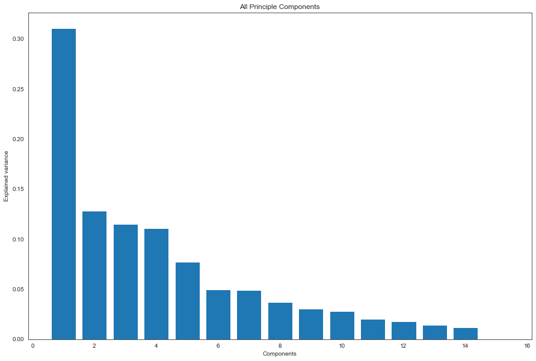

```python
# Run PCA and fit the model
myPCA = PCA()
x     = myPCA.fit(chile_data_s)

# Plotting the varaince explained by each component
plt.bar(range(1,len(x.explained_variance_ )+1),x.explained_variance_ratio_)
plt.ylabel('Explained variance')
plt.xlabel('Components')
plt.title('All Principle Components')
pass
```

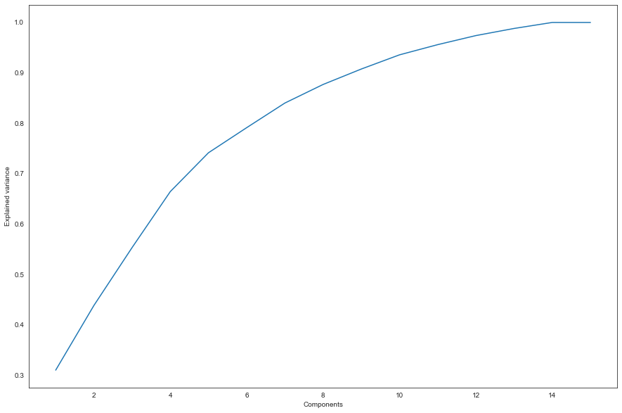

```python
# Deciding on the number of principal componenets to chose
plt.plot(range(1, len(x.explained_variance_)+1), x.explained_variance_ratio_.cumsum())
plt.ylabel('Explained variance')
plt.xlabel('Components')
pass
```

```python
# Calculate the numeric values of principal components
x.explained_variance_ratio_.cumsum()
```

```
array([0.31056369, 0.43880412, 0.5536584 , 0.66462302, 0.74164543,
       0.79139787, 0.84021097, 0.87701332, 0.90763632, 0.93576179,
       0.95598485, 0.97396892, 0.98809104, 1.        , 1.        ])
```

Thus, I will choose to use only first 7 components, which explain 84% of variance.

```python
# Explore the importance of each feature for principle components
pca = PCA(n_components = 7).fit(chile_data_s)
```

```python
vars_ = pca.explained_variance_ratio_
c_names = chile_data_s.columns
sum_ = 0
```

```python
print('Variance:  Projected dimension')
print('------------------------------')
for idx, row in enumerate(pca.components_):
    output = 100.0*vars_[idx]
    output = '{0:4.1f}%:    '.format(100.0 * vars_[idx])
    output += " + ".join("{0:5.2f} * {1:s}".format(val, name) \
                      for val, name in zip(row, c_names))
    sum_ += 100*vars_[idx]
    print(output)

print('Total variance explained by the 7 components {0:4.1f}%'.format(sum_))
# Total variance explained by the 7 components 84.0%
```

```
Variance:  Projected dimension
------------------------------
31.1%:    -0.00 * CULTURAL EVENTS SCHEDULED THROUGHOUT THE YEAR +  0.18 * NUMBER OF CULTURAL CENTERS +  0.04 * WORLD CULTURAL HERITAGE SITES + -0.01 * NUMBER OF ARCHEOLOGICAL SITES +  0.19 * NATIONAL MONUMENTS +  0.18 * MUSEUMS +  0.04 * % OF POPULATION THAT ATTENDS MUSEUMS +  0.18 * THEATERS +  0.1…
12.8%:     0.21 * CULTURAL EVENTS SCHEDULED THROUGHOUT THE YEAR +  0.02 * NUMBER OF CULTURAL CENTERS +  0.13 * WORLD CULTURAL HERITAGE SITES +  0.00 * NUMBER OF ARCHEOLOGICAL SITES + -0.05 * NATIONAL MONUMENTS + -0.08 * MUSEUMS + -0.12 * % OF POPULATION THAT ATTENDS MUSEUMS + -0.08 * THEATERS + -0.1…
11.5%:    -0.07 * CULTURAL EVENTS SCHEDULED THROUGHOUT THE YEAR +  0.01 * NUMBER OF CULTURAL CENTERS +  0.20 * WORLD CULTURAL HERITAGE SITES +  0.13 * NUMBER OF ARCHEOLOGICAL SITES +  0.00 * NATIONAL MONUMENTS + -0.04 * MUSEUMS +  0.19 * % OF POPULATION THAT ATTENDS MUSEUMS + -0.07 * THEATERS + -0.0…
11.1%:    -0.07 * CULTURAL EVENTS SCHEDULED THROUGHOUT THE YEAR +  0.06 * NUMBER OF CULTURAL CENTERS + -0.01 * WORLD CULTURAL HERITAGE SITES + -0.16 * NUMBER OF ARCHEOLOGICAL SITES +  0.03 * NATIONAL MONUMENTS + -0.00 * MUSEUMS + -0.12 * % OF POPULATION THAT ATTENDS MUSEUMS +  0.05 * THEATERS +  0.0…
 7.7%:    -0.13 * CULTURAL EVENTS SCHEDULED THROUGHOUT THE YEAR +  0.05 * NUMBER OF CULTURAL CENTERS +  0.06 * WORLD CULTURAL HERITAGE SITES + -0.06 * NUMBER OF ARCHEOLOGICAL SITES + -0.06 * NATIONAL MONUMENTS +  0.08 * MUSEUMS + -0.03 * % OF POPULATION THAT ATTENDS MUSEUMS + -0.03 * THEATERS + -0.0…
 5.0%:     0.16 * CULTURAL EVENTS SCHEDULED THROUGHOUT THE YEAR + -0.05 * NUMBER OF CULTURAL CENTERS +  0.12 * WORLD CULTURAL HERITAGE SITES +  0.26 * NUMBER OF ARCHEOLOGICAL SITES +  0.00 * NATIONAL MONUMENTS + -0.07 * MUSEUMS +  0.02 * % OF POPULATION THAT ATTENDS MUSEUMS + -0.02 * THEATERS +  0.0…
 4.9%:     0.14 * CULTURAL EVENTS SCHEDULED THROUGHOUT THE YEAR + -0.08 * NUMBER OF CULTURAL CENTERS + -0.06 * WORLD CULTURAL HERITAGE SITES + -0.16 * NUMBER OF ARCHEOLOGICAL SITES + -0.01 * NATIONAL MONUMENTS + -0.09 * MUSEUMS + -0.12 * % OF POPULATION THAT ATTENDS MUSEUMS +  0.05 * THEATERS +  0.0…
Total variance explained by the 7 components 84.0%
```

```python
# We also can see this information for each component separately
# For instance, these are results for the Principal Component 1 (sorted)
pd.DataFrame(np.column_stack((chile_data_s.columns, pca.components_[0]))).sort_values(by = 1, ascending = False)[0:10]
# The same logic can be applied to all other principal components
```

|  | 0 | 1 |
| --- | --- | --- |
| 55 | NUMBER OF COLLEGE STUDENTS IN TOURISM RELATED ... | 0.190494 |
| 75 | NUMBER OF VEHICLES | 0.190208 |
| 4 | NATIONAL MONUMENTS | 0.189354 |
| 10 | GALERIES | 0.189213 |
| 26 | % LAND THAT CORRESPONDS TO HUMAN SETTLEMENTS | 0.189184 |
| 56 | AVERAGE NUMBER OF GRADUATES IN TOURISM-RELATED... | 0.188407 |
| 58 | CERTIFIED WORKERS ON HIGHLY-COMPETITIVE TOURIS... | 0.186772 |
| 22 | CULTURAL SITES LEVEL I (LOCAL) | 0.18646 |
| 54 | TOURISM-ORIENTED INSTITUTIONS | 0.185938 |
| 66 | NUMBER OF CERTIFIED CONSULTANTS FOR TOURISM-RE... | 0.185628 |

```python
# Calculate loadings
myPCA = PCA(n_components = 7)
pca_model = myPCA.fit(chile_data_s)

# Print
print("The loadings are are \n {}".format(pca_model.components_))
```

```
The loadings are are
 [[-3.14114900e-03  1.84068625e-01  3.83359417e-02 -7.23593573e-03
   1.89353901e-01  1.77680758e-01  4.28019298e-02  1.80796045e-01
   1.75712415e-01  1.83302748e-01  1.89212730e-01 -9.19039413e-02
   1.76693481e-01 -2.21942700e-03  3.56288633e-03  8.23925177e-02
   2.84099782e-04 -2.43316126e-02  3.35399312e-02  6.57574975e-02
   6.30600048e-02  1.46854019e-01  1.86459901e-01  1.19268998e-01
  -8.06923280e-02 -9.45586597e-02  1.89183791e-01 -2.88927325e-03
   1.72762172e-01 -2.65201596e-02  3.40290978e-02  4.57865305e-02
  -6.73259888e-02 -6.92007117e-02 -6.71394790e-02 -7.84791184e-02
  -2.80755261e-02 -4.30200657e-02 -5.47976947e-02  6.41348528e-02
  -4.28115761e-02 -3.18959588e-02 -3.52137965e-02 -6.17039475e-03
  -4.07668290e-02  1.97692844e-02 -4.31764941e-02  6.85026270e-03
   5.62070211e-02 -8.74642620e-03 -1.40782405e-02 -8.67275209e-03
   8.70522744e-02 -1.30423099e-01  1.85937860e-01  1.90493767e-01
   1.88407186e-01 -8.48640113e-02  1.86771725e-01  1.45060360e-01
  -1.22197474e-01  1.57458526e-01 -8.17831424e-02  1.13535145e-01
   4.18260822e-02  8.50945867e-02  1.85627819e-01  1.58962803e-01
   6.89621278e-02  1.47484947e-01  1.73435409e-01  1.05103990e-01
  -3.92786493e-03 -1.35278888e-01  1.71430863e-01  1.90208045e-01
  -5.07673319e-03  8.51317020e-03  1.55771270e-01  5.19587047e-02
  -9.07753996e-02]
 [ 2.08129879e-01  2.00381337e-02  1.30573184e-01  1.34521871e-04
  -5.32771112e-02 -8.32420879e-02 -1.22071270e-01 -7.56304913e-02
  -1.03919326e-01  1.49676046e-02 -6.23824409e-02 -8.07768961e-02
  -1.17584769e-01  2.25300635e-01  1.86702024e-01  1.08528984e-01
   1.79399948e-01  1.53393460e-01 -6.64189070e-02  1.41733533e-01
   9.71631175e-02  6.35786347e-03 -3.68219820e-02  1.26038703e-01
  -5.14633804e-02 -1.58381029e-01 -5.32643822e-02 -1.54694193e-01
   4.17743171e-02 -5.99645631e-03  2.19965558e-01  1.75423105e-01
  -2.01258744e-02  4.00046020e-02  5.37004277e-02 -8.52618546e-02
   7.08472774e-02  9.22336771e-03 -9.00940945e-02  1.51686044e-01
  -7.34568918e-02 -1.40585972e-02 -3.45874129e-02  1.91863588e-01
  -3.98625987e-02  8.94904412e-02  5.94509046e-02 -5.83338531e-02
  -3.89946474e-02 -2.36823817e-01  7.95661146e-02 -2.75992881e-02
  -1.45900748e-01 -1.53436365e-01  2.92713108e-04 -6.62852834e-02
  -7.87239054e-02 -1.67820462e-01 -4.77035196e-02 -1.19312067e-01
  -1.71787472e-01  6.90353511e-02 -1.87166552e-01 -1.69218374e-01
   1.23212242e-01  3.91857226e-02 -8.41147052e-02  6.19563405e-02
   9.12803135e-02 -9.30982972e-04 -1.28619837e-01 -8.62534186e-02
```

[output cut: 93 more lines]

```
  -3.55551554e-02  6.64994458e-02  5.21784703e-02 -1.22874044e-02
  -7.65324646e-02 -9.23477433e-02 -1.39856925e-01 -1.03268795e-01
  -6.25883216e-02 -1.03885191e-01 -1.31332910e-01 -1.89306312e-01
  -5.86602533e-02  3.13768208e-02  4.04644361e-02  6.61098880e-02
  -2.00074078e-01  1.21480634e-01 -2.59100364e-01 -1.76180794e-01
   1.14002480e-01  6.32897833e-02  9.43841153e-02  7.18107280e-02
   5.75195472e-02 -2.86388899e-02  1.40663471e-01  1.72075733e-02
  -5.84280849e-02  1.12825002e-01 -6.80315321e-02  9.01021536e-03
   2.55045223e-02  2.37781318e-02  7.28038422e-02 -4.11315590e-04
   5.67069207e-02 -5.99032863e-02 -8.20432205e-02 -6.27289435e-02
   2.03800519e-01 -2.37535914e-02  5.58843721e-02  4.49488482e-02
   2.73204518e-01 -2.27436579e-01  5.40044448e-02  1.19206096e-01
   5.49289823e-02  1.45606061e-02  1.26168742e-02  3.02840805e-02
  -1.63240608e-01 -3.43276574e-02  2.85211128e-02 -6.42658976e-02
  -1.42393773e-01]]
```

```python
# Calculate factor scores
pca_model = myPCA.fit_transform(chile_data_s)
PCcomponents = pd.DataFrame(data = pca_model, columns = ['PC1', 'PC2', 'PC3', 'PC4', 'PC5', 'PC6', 'PC7'])
print("\n The Factor scores are")
PCcomponents
```

```
 The Factor scores are
```

|  | PC1 | PC2 | PC3 | PC4 | PC5 | PC6 | PC7 |
| --- | --- | --- | --- | --- | --- | --- | --- |
| 0 | -2.383281 | -1.109669 | 0.442911 | -1.056445 | -2.389920 | 5.465501 | 1.401569 |
| 1 | -1.605695 | -2.194596 | 0.066043 | -3.100099 | 1.369886 | 2.132449 | 0.189697 |
| 2 | -1.167348 | -3.049750 | 1.006051 | -3.053233 | 1.634394 | -0.893234 | -3.658888 |
| 3 | -3.025022 | -1.699419 | -1.202507 | -3.972159 | 1.607307 | 0.296626 | -1.101372 |
| 4 | 0.073189 | 3.465537 | 1.714289 | -3.159171 | 1.208559 | -2.995646 | 4.572768 |
| 5 | 5.668656 | 5.236200 | 7.758784 | -1.350007 | -1.611529 | 0.239618 | -2.073582 |
| 6 | 16.067894 | -4.604195 | -2.003572 | 1.233211 | -1.219080 | 0.009925 | 1.331711 |
| 7 | -0.532460 | 4.118122 | -2.608112 | -1.704279 | -1.274229 | 0.316562 | 0.933148 |
| 8 | -0.899611 | 3.172633 | -3.532212 | -0.042876 | -0.495034 | 0.111081 | 0.177790 |
| 9 | 2.200815 | 0.421622 | -3.574500 | -0.608841 | 2.179288 | -2.283347 | -2.283990 |
| 10 | -1.140493 | 4.036502 | -2.692022 | 5.484836 | -2.804461 | 0.207315 | -2.444356 |
| 11 | -2.273861 | 0.224006 | -2.586635 | 0.776081 | 1.512589 | 0.372649 | 0.725168 |
| 12 | -0.573606 | -0.264579 | 3.494012 | 6.445622 | 6.264373 | 1.264472 | 0.778434 |
| 13 | -6.021544 | -2.594919 | 0.337870 | 2.983004 | -2.188228 | -2.134614 | 1.575641 |
| 14 | -4.387633 | -5.157493 | 3.379600 | 1.124357 | -3.793915 | -2.109356 | -0.123738 |

Fit different dimentions

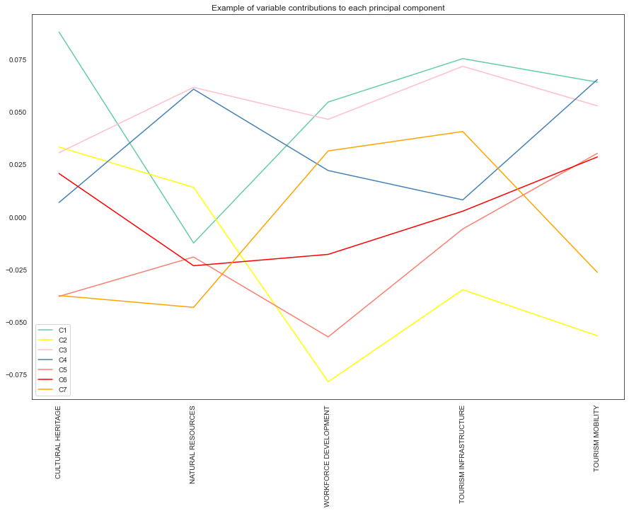

```python
# Example of different variables in each component

# Fit the model
myPCA = PCA(n_components = 7)
pca_model = myPCA.fit(chile_data_s)
y_axis = [0,0,0,0,0,0,0]
for i in range(0,7):
    y_axis[i]=[np.mean(pca_model.components_[i][0:24]), np.mean(pca_model.components_[i][24:47]),
               np.mean(pca_model.components_[i][47:59]), np.mean(pca_model.components_[i][59:69]),
               np.mean(pca_model.components_[i][69:81])]
# Plot
x_axis = ['CULTURAL HERITAGE', 'NATURAL RESOURCES', 'WORKFORCE DEVELOPMENT', 'TOURISM INFRASTRUCTURE', 'TOURISM MOBILITY']
plt.plot(x_axis,y_axis[0], color = 'mediumaquamarine', label = "C1")
plt.plot(x_axis,y_axis[1], color = 'yellow', label = "C2")
plt.plot(x_axis,y_axis[2], color = 'pink', label = "C3")
plt.plot(x_axis,y_axis[3], color = 'steelblue', label = "C4")
plt.plot(x_axis,y_axis[4], color = 'salmon', label = "C5")
plt.plot(x_axis,y_axis[5], color = 'red', label = "C6")
plt.plot(x_axis,y_axis[6], color = 'orange', label = "C7")
plt.xticks(rotation = 90)
plt.title('Example of variable contributions to each principal component')
plt.legend()
pass
```

Developing a scoring system for 5 dimensions

1. Calculate a weighted average for each variable in principal components.

```python
# Creating a dataframe of weights
weights = pd.DataFrame(np.column_stack((chile_data_s.columns, pca_model.components_[0] *
                                        pca_model.explained_variance_ratio_[0],
                                        pca_model.components_[1] * pca_model.explained_variance_ratio_[1],
                                        pca_model.components_[2] * pca_model.explained_variance_ratio_[2],
                                        pca_model.components_[3] * pca_model.explained_variance_ratio_[3],
                                        pca_model.components_[4] * pca_model.explained_variance_ratio_[4],
                                        pca_model.components_[5] * pca_model.explained_variance_ratio_[5],
                                        pca_model.components_[6] * pca_model.explained_variance_ratio_[6])))
weights = weights.set_index(0)

# Create a weighted average
weights['weighted_average'] = weights.sum(axis = 1)/np.sum(pca_model.explained_variance_ratio_)

# Print
weights
```

| 0 | 1 | 2 | 3 | 4 | 5 | 6 | 7 | weighted_average |
| --- | --- | --- | --- | --- | --- | --- | --- | --- |
| CULTURAL EVENTS SCHEDULED THROUGHOUT THE YEAR | -0.000975527 | 0.0266907 | -0.00776867 | -0.00736376 | -0.00998854 | 0.00791649 | 0.00662895 | 0.018019 |
| NUMBER OF CULTURAL CENTERS | 0.057165 | 0.0025697 | 0.000777646 | 0.00662925 | 0.00367884 | -0.00227677 | -0.00386749 | 0.076976 |
| WORLD CULTURAL HERITAGE SITES | 0.0119058 | 0.0167448 | 0.0227327 | -0.00146141 | 0.00432993 | 0.00578716 | -0.00309997 | 0.067767 |
| NUMBER OF ARCHEOLOGICAL SITES | -0.00224722 | 1.72511e-05 | 0.0154391 | -0.0177918 | -0.0048666 | 0.0131398 | -0.00790565 | -0.005017 |
| NATIONAL MONUMENTS | 0.0588064 | -0.00683228 | 0.000419941 | 0.00348383 | -0.00428597 | 7.14347e-05 | -0.000379001 | 0.061038 |
| MUSEUMS | 0.0551812 | -0.010675 | -0.00425686 | -0.000295855 | 0.00578765 | -0.00351773 | -0.00434223 | 0.045085 |
| % OF POPULATION THAT ATTENDS MUSEUMS | 0.0132927 | -0.0156545 | 0.0221738 | -0.0134796 | -0.00214904 | 0.00121679 | -0.00576478 | -0.000434 |
| THEATERS | 0.0561487 | -0.00969889 | -0.0086095 | 0.00505427 | -0.00253462 | -0.000754228 | 0.00227833 | 0.049849 |
| NUMBER OF THEATER PLAYS PER YEAR | 0.0545699 | -0.0133267 | -0.00769911 | 0.00401077 | -0.00321892 | 3.03424e-05 | 0.00355314 | 0.045131 |
| LIBRARIES | 0.0569272 | 0.00191945 | -0.00606683 | 0.00935061 | -0.00377091 | -0.00266392 | -0.00249445 | 0.063319 |
| GALERIES | 0.0587626 | -0.00799995 | -0.00408002 | 0.0039442 | -0.00357834 | -0.000781754 | 3.2159e-05 | 0.055104 |
| % OF POPULATION ASSOCIATED TO AN INDIGENOUS GROUP | -0.028542 | -0.0103589 | 0.00309414 | 0.0237984 | -0.00746216 | 0.00807529 | -0.000435545 | -0.014081 |
| NUMBER OF EXHIBITS | 0.0548746 | -0.0150791 | -0.00712977 | 0.0036252 | -0.00166059 | -0.0020678 | 0.000988989 | 0.039932 |
| ARTISTIC EVENTS (MUSIC, DANCE AND FOLKLOR, THEATRE, ETC) PER YEAR | -0.000689273 | 0.0288927 | -0.0108991 | 0.00188328 | -0.00887116 | 0.000406731 | -0.00297845 | 0.009218 |
| MAJOR SPORTS EVENTS PER YEAR | 0.0011065 | 0.0239427 | -0.00517894 | 0.0109465 | -0.0117677 | 0.00139891 | -0.0070572 | 0.015937 |
| OBSERVATORIES, ZOOS, AQUARIUMS, BOTANICAL GARDENS | 0.0255881 | 0.0139178 | 0.0118439 | -0.0149135 | 0.000379578 | -0.00852919 | 0.0080973 | 0.043304 |
| ARTWORK SITES | 8.82311e-05 | 0.0230063 | -0.0171813 | 0.00543168 | -0.0121157 | 0.00232065 | -0.00322037 | -0.001988 |
| POPULAR ARCHITECTURE SITES | -0.00755652 | 0.0196712 | 0.0213494 | -0.00988958 | 0.00582131 | -0.000587849 | 0.0105681 | 0.046864 |
| HISTORICAL SITES | 0.0104163 | -0.00851759 | 0.00963948 | -0.0110673 | 0.00160914 | -0.00604754 | -0.0179631 | -0.026101 |
| LOCAL MARKETS | 0.0204219 | 0.018176 | -0.00523612 | 0.0207626 | -0.00679206 | 0.00635744 | -0.00587245 | 0.056911 |
| CULTURAL SITES LEVEL III (INTERNATIONAL) | 0.0195841 | 0.0124602 | 0.02641 | -0.00731053 | -0.00673553 | 0.00464841 | -0.00669871 | 0.050414 |
| CULTURA SITES LEVEL II (NATIONAL) | 0.0456075 | 0.000815335 | 0.0203066 | 0.000521235 | 0.000885594 | 0.00486661 | 0.000904182 | 0.087963 |
| CULTURAL SITES LEVEL I (LOCAL) | 0.0579077 | -0.00472207 | -0.00628877 | 0.00685833 | 0.00136299 | -0.00440822 | -0.000688438 | 0.059534 |
| HERITAGE ARCHITECTURAL HOUSES | 0.0370406 | 0.0161633 | 0.020198 | -0.00465359 | -0.0040924 | -5.65089e-06 | -0.00417529 | 0.071976 |
| % OF LAND THAT CORRESPONDS TO FORESTS | -0.0250601 | -0.00659969 | -0.00121003 | 0.0258681 | 0.0097466 | 0.000924828 | -0.00173556 | 0.002302 |
| NATIONAL PROTECTED SITES (%) | -0.0293665 | -0.0203109 | 0.0119173 | 0.0136986 | -0.0132317 | -0.00254444 | 0.00324604 | -0.043550 |
| % LAND THAT CORRESPONDS TO HUMAN SETTLEMENTS | 0.0587536 | -0.00683065 | -0.00270443 | 0.00274883 | -0.00548468 | 0.000236956 | 0.00254699 | 0.058636 |
| TOXIC WASTE DISPOSAL (TONS/100 hab.) | -0.000897303 | -0.019838 | 0.00349807 | -0.00613216 | -0.00380111 | 0.0144611 | -0.000599786 | -0.015840 |
| NUMBER OF ENVIRONMENTAL COMPLAINTS PRESENTED | 0.0536537 | 0.00535716 | 0.00627374 | 0.00413222 | -0.0110528 | -8.44809e-05 | -0.00373579 | 0.064917 |
| ENVIRONMENTAL ISSUES PER MILLION HABITANTS | -0.0082362 | -0.000768988 | -0.00960573 | -0.0148853 | 0.00566909 | -0.00071087 | -0.00450778 | -0.039330 |

[output cut: 51 more lines]

1. Calculate a score for each dimension.
- Multiply weighted average of a variable by each standartized value in each column and sum up results, receiving a final score.

```python
# StandardScaler = X - mean(x)/ sd(x)
```

```python
# Ranking for dimension 1: CULTURAL HERITAGE AND EVENTS

# Create a dataframe for relevant variables
dim1 = chile_data_s.iloc[:, 0:24].mul(weights['weighted_average'][0:24], axis = 1)

# Create a score ranking
dim1['Ranking 1'] = dim1.sum(axis = 1)

# Sort by score
dim1.sort_values(by = 'Ranking 1', ascending = False)
```

| Region | CULTURAL EVENTS SCHEDULED THROUGHOUT THE YEAR | NUMBER OF CULTURAL CENTERS | WORLD CULTURAL HERITAGE SITES | NUMBER OF ARCHEOLOGICAL SITES | NATIONAL MONUMENTS | MUSEUMS | % OF POPULATION THAT ATTENDS MUSEUMS | THEATERS | NUMBER OF THEATER PLAYS PER YEAR | LIBRARIES | GALERIES | % OF POPULATION ASSOCIATED TO AN INDIGENOUS GROUP | NUMBER OF EXHIBITS | ARTISTIC EVENTS (MUSIC, DANCE AND FOLKLOR, THEATRE, ETC) PER YEAR | MAJOR SPORTS EVENTS PER YEAR | OBSERVATORIES, ZOOS, AQUARIUMS, BOTANICAL GARDENS | ARTWORK SITES | POPULAR ARCHITECTURE SITES | HISTORICAL SITES | LOCAL MARKETS | CULTURAL SITES LEVEL III (INTERNATIONAL) | CULTURA SITES LEVEL II (NATIONAL) | CULTURAL SITES LEVEL I (LOCAL) | HERITAGE ARCHITECTURAL HOUSES | Ranking 1 |
| --- | --- | --- | --- | --- | --- | --- | --- | --- | --- | --- | --- | --- | --- | --- | --- | --- | --- | --- | --- | --- | --- | --- | --- | --- | --- |
| Metropolitana | -0.011101 | 0.209641 | -0.037883 | 0.003515 | 0.212726 | 0.137391 | -0.000228 | 0.181054 | 0.167948 | 0.193215 | 0.192378 | 0.011488 | 0.141437 | -0.006159 | -0.007249 | 0.033648 | 0.000668 | -0.065128 | 0.002683 | 0.039631 | -0.004171 | 0.186398 | 0.194741 | 0.061613 | 1.838257 |
| Valparaíso | 0.004176 | 0.109895 | 0.189416 | -0.007713 | 0.050884 | 0.011327 | -0.000523 | -0.008631 | -0.008993 | 0.045601 | 0.030565 | 0.012800 | -0.003949 | 0.004927 | 0.010874 | 0.054678 | 0.000668 | 0.062944 | -0.029509 | 0.039631 | 0.183522 | 0.205113 | 0.017845 | 0.242556 | 1.218104 |
| Los Lagos | -0.015684 | 0.041648 | 0.075766 | 0.004003 | -0.013720 | 0.005846 | 0.000021 | -0.005620 | -0.010411 | -0.006376 | -0.023373 | -0.012859 | -0.009333 | -0.006159 | -0.007249 | -0.029442 | 0.001469 | 0.033160 | 0.018778 | 0.016767 | -0.022046 | 0.081596 | 0.003879 | -0.011414 | 0.109248 |
| O'Higgins | 0.031673 | -0.016099 | 0.075766 | -0.000391 | -0.011722 | -0.021559 | -0.000173 | 0.009434 | -0.011007 | 0.004020 | -0.032363 | 0.014696 | -0.014718 | 0.019708 | 0.028997 | 0.033648 | -0.004942 | 0.006354 | 0.018778 | -0.028961 | -0.022046 | -0.026949 | -0.031034 | 0.043356 | 0.064466 |
| Biobío | -0.009573 | 0.083647 | -0.037883 | 0.004003 | -0.017050 | 0.055176 | 0.000104 | 0.006423 | -0.004283 | 0.060154 | 0.030565 | 0.011780 | 0.033744 | -0.006159 | -0.007249 | -0.029442 | -0.000134 | -0.041301 | -0.034874 | -0.006097 | -0.022046 | -0.094322 | 0.059741 | 0.005220 | 0.040143 |
| Coquimbo | 0.017924 | -0.047598 | -0.037883 | 0.003026 | -0.021712 | -0.016078 | 0.000159 | -0.017664 | -0.015859 | -0.025087 | -0.014383 | 0.014987 | -0.020103 | -0.002463 | -0.007249 | 0.117768 | 0.001068 | 0.125490 | 0.021461 | -0.028961 | -0.022046 | -0.023206 | -0.003103 | -0.010197 | -0.011710 |
| Araucanía | 0.010286 | -0.016099 | -0.037883 | 0.003026 | 0.007593 | -0.027040 | 0.000629 | -0.005620 | -0.013050 | 0.049759 | 0.003596 | -0.026417 | -0.020103 | 0.012317 | 0.047120 | -0.029442 | -0.003740 | -0.032365 | 0.010731 | 0.176817 | -0.022046 | -0.086836 | 0.006207 | -0.041436 | -0.033997 |
| Maule | 0.027090 | 0.004900 | -0.037883 | 0.003515 | -0.020380 | -0.016078 | 0.000823 | -0.002609 | 0.000513 | -0.010534 | -0.023373 | 0.015133 | -0.014718 | 0.019708 | -0.007249 | -0.029442 | -0.002538 | 0.000397 | 0.016096 | 0.016767 | -0.022046 | 0.006737 | -0.000776 | -0.041841 | -0.117790 |
| Tarapacá | -0.017211 | -0.058098 | 0.075766 | -0.002343 | -0.007726 | -0.027040 | -0.000071 | -0.023686 | -0.013079 | -0.045878 | -0.023373 | -0.000904 | -0.014718 | -0.006159 | -0.007249 | -0.029442 | 0.001469 | 0.021246 | -0.000000 | -0.028961 | 0.004767 | -0.004492 | -0.038017 | -0.049550 | -0.294748 |
| Antofagasta | -0.015684 | -0.037098 | -0.037883 | -0.009665 | -0.002398 | 0.033252 | -0.000680 | -0.005620 | -0.012369 | -0.039641 | -0.014383 | 0.009156 | -0.009333 | -0.002463 | -0.007249 | 0.033648 | 0.001068 | -0.008538 | -0.072431 | -0.051826 | -0.004171 | -0.015720 | -0.005431 | -0.023991 | -0.299452 |
| Arica y Parinacota | 0.030145 | -0.073847 | -0.037883 | -0.010641 | -0.037697 | -0.032521 | -0.000191 | -0.023686 | -0.015150 | -0.045878 | -0.014383 | -0.019565 | -0.014718 | -0.006159 | -0.007249 | -0.029442 | -0.000134 | 0.015289 | 0.016096 | 0.016767 | 0.018173 | -0.011977 | -0.049655 | -0.025613 | -0.359919 |
| Los Ríos | -0.012628 | -0.037098 | -0.037883 | 0.003515 | -0.034366 | -0.010597 | 0.000353 | -0.020675 | -0.015462 | -0.045878 | -0.014383 | -0.006881 | -0.009333 | -0.002463 | -0.007249 | -0.008412 | 0.001469 | -0.050236 | 0.013413 | -0.006097 | -0.022046 | -0.094322 | -0.021724 | -0.027236 | -0.466223 |
| Atacama | -0.004990 | -0.031849 | -0.037883 | 0.000098 | -0.033034 | -0.016078 | 0.000002 | -0.029707 | -0.014043 | -0.045878 | -0.032363 | 0.006531 | -0.020103 | -0.006159 | -0.007249 | -0.029442 | 0.001469 | -0.026409 | 0.013413 | -0.051826 | -0.013109 | -0.023206 | -0.049655 | -0.036162 | -0.487630 |
| Magallanes y Antártica | -0.017211 | -0.068597 | -0.037883 | 0.003026 | -0.026374 | -0.021559 | -0.000707 | -0.023686 | -0.018016 | -0.041720 | -0.032363 | -0.015629 | -0.003949 | -0.006159 | -0.007249 | -0.029442 | 0.000668 | -0.032365 | -0.016096 | -0.051826 | -0.013109 | -0.041921 | -0.040345 | -0.035756 | -0.578266 |
| Aysén | -0.017211 | -0.063347 | -0.037883 | 0.003026 | -0.045023 | -0.054445 | 0.000482 | -0.029707 | -0.016739 | -0.045878 | -0.032363 | -0.014316 | -0.020103 | -0.006159 | -0.007249 | -0.029442 | 0.001469 | -0.008538 | 0.021461 | -0.051826 | -0.017578 | -0.056893 | -0.042672 | -0.049550 | -0.620483 |

```python
# Ranking for dimension 2: NATURAL RESOURCES AND SUSTAINABILITY; chile_data_s.iloc[:, 24:47]

# Create a dataframe for relevant variables
dim2 = chile_data_s.iloc[:, 24:47].mul(weights['weighted_average'][24:47], axis = 1)

# Create a score ranking
dim2['Ranking'] = dim2.sum(axis = 1)

# Sort by score
dim2.sort_values(by = 'Ranking', ascending = False)
```

| Region | % OF LAND THAT CORRESPONDS TO FORESTS | NATIONAL PROTECTED SITES (%) | % LAND THAT CORRESPONDS TO HUMAN SETTLEMENTS | TOXIC WASTE DISPOSAL (TONS/100 hab.) | NUMBER OF ENVIRONMENTAL COMPLAINTS PRESENTED | ENVIRONMENTAL ISSUES PER MILLION HABITANTS | NUMBER OF BEACHES AND BEACH RESORTS | LAND AFFECTED BY WILDFIRES | NATURAL PROTECTED SITES LEVEL III (INTERNATIONAL) | NATURAL PROTECTED SITES LEVEL II (NATIONAL) | RIVERS, LAKES AND WATERFALLS | MOUNTAINS, VOLCANOES AND MOUNTAIN SYSTEMS | GEISERS AND THERMAL CENTERS | PIERS AND SEASHORES | GLACIERS AND WINTER VACATION LOCATIONS | VALLEYS | DESERTS AND DUNES | ISLANDS AND PENINSULAS | PALEONTOLOGY SITES | HIKING TRAILS | PRESERVED SITES | SEASHORE PROTECTED SITES | BIOSHPERE RESERVES | Ranking |
| --- | --- | --- | --- | --- | --- | --- | --- | --- | --- | --- | --- | --- | --- | --- | --- | --- | --- | --- | --- | --- | --- | --- | --- | --- |
| Valparaíso | -0.002110 | 0.024609 | 0.039856 | 0.002726 | 0.130906 | 0.016155 | 0.138827 | 1.428694e-01 | -0.004340 | -0.007885 | 0.015168 | 0.058541 | -0.012212 | -0.003362 | 0.013162 | 0.141266 | 0.020492 | -0.031952 | 0.052686 | 0.023894 | -2.091606e-02 | 0.165013 | 0.060481 | 0.963874 |
| Los Lagos | 0.004993 | -0.011591 | -0.023760 | 0.007507 | -0.037402 | 0.016155 | 0.001341 | -2.944606e-02 | -0.003323 | -0.001434 | -0.005788 | -0.040123 | 0.016711 | -0.001216 | 0.013162 | -0.020953 | 0.034463 | 0.189803 | 0.052686 | -0.011195 | 1.603565e-01 | 0.165013 | 0.015120 | 0.491080 |
| Coquimbo | -0.002925 | 0.030916 | -0.018026 | 0.019587 | -0.037402 | 0.016155 | 0.065054 | 9.449997e-03 | 0.004814 | 0.003942 | 0.009180 | 0.058541 | -0.021852 | -0.007118 | 0.031109 | 0.100711 | 0.034463 | 0.032429 | 0.023416 | -0.011195 | -2.091606e-02 | 0.094293 | 0.015120 | 0.429749 |
| Metropolitana | -0.002058 | 0.029545 | 0.209352 | -0.008381 | 0.172984 | 0.016155 | -0.059018 | -2.855194e-02 | 0.005832 | 0.006738 | 0.019658 | 0.028941 | -0.007391 | 0.004149 | 0.001197 | 0.009463 | 0.034463 | -0.031952 | 0.052686 | -0.011195 | -2.091606e-02 | -0.047146 | -0.030240 | 0.344312 |
| Los Ríos | 0.003538 | 0.013090 | -0.019436 | 0.006671 | -0.051428 | 0.016155 | -0.025485 | -2.595685e-02 | 0.006849 | 0.000717 | 0.000200 | 0.028941 | 0.040813 | 0.002003 | 0.031109 | -0.071647 | 0.034463 | 0.003815 | 0.023416 | -0.011195 | 8.050117e-17 | -0.047146 | 0.015120 | -0.025394 |
| Maule | -0.001225 | 0.030368 | -0.016154 | 0.009980 | 0.018701 | 0.016155 | 0.001341 | -8.309761e-03 | 0.008883 | 0.003082 | -0.014769 | -0.059856 | 0.007070 | 0.001466 | -0.004786 | 0.050018 | -0.007451 | -0.031952 | 0.052686 | 0.011362 | -2.091606e-02 | -0.047146 | -0.030240 | -0.031692 |
| Araucanía | 0.001161 | 0.005686 | -0.015533 | 0.004891 | 0.032727 | 0.016155 | 0.024815 | -2.542342e-02 | -0.013494 | -0.009605 | -0.056680 | -0.040123 | 0.055274 | 0.002539 | -0.010769 | 0.019602 | 0.034463 | -0.024798 | -0.035124 | 0.046451 | -2.091606e-02 | -0.047146 | 0.015120 | -0.040727 |
| O'Higgins | -0.001423 | 0.024334 | 0.000648 | 0.017376 | 0.004675 | -0.033219 | -0.018779 | 3.474824e-02 | 0.003797 | 0.002652 | 0.018161 | 0.028941 | -0.017032 | 0.003076 | -0.010769 | -0.031092 | 0.006520 | -0.024798 | 0.023416 | 0.006349 | -2.091606e-02 | -0.047146 | -0.030240 | -0.060718 |
| Arica y Parinacota | 0.000000 | -0.028046 | -0.014626 | -0.022604 | -0.037402 | 0.016155 | -0.042252 | 5.766857e-18 | -0.004340 | 0.004587 | 0.013671 | -0.000658 | 0.002250 | 0.003076 | 0.031109 | -0.000676 | 0.006520 | -0.031952 | 0.052686 | -0.006182 | 8.050117e-17 | -0.047146 | 0.015120 | -0.090709 |
| Tarapacá | -0.003010 | 0.007057 | -0.028814 | -0.045961 | -0.037402 | 0.016155 | -0.005365 | 5.766857e-18 | 0.006849 | 0.006093 | 0.018161 | 0.048674 | 0.007070 | 0.001466 | 0.031109 | -0.031092 | -0.049366 | -0.003338 | -0.005854 | -0.003676 | -2.091606e-02 | -0.047146 | -0.030240 | -0.169546 |
| Biobío | -0.000079 | 0.024334 | 0.002033 | 0.011506 | -0.023376 | -0.025254 | 0.024815 | -1.067256e-02 | 0.005832 | 0.005878 | -0.008781 | 0.028941 | -0.017032 | 0.002003 | 0.013162 | -0.061508 | 0.034463 | -0.024798 | -0.181473 | -0.011195 | -2.091606e-02 | -0.047146 | -0.030240 | -0.309507 |
| Antofagasta | 0.000000 | 0.024334 | -0.028808 | 0.001297 | -0.023376 | 0.016155 | 0.014755 | 5.766857e-18 | 0.003797 | 0.001362 | 0.007684 | -0.069722 | -0.012212 | -0.003362 | 0.025127 | -0.020953 | -0.105252 | 0.010969 | -0.064394 | -0.011195 | -2.091606e-02 | -0.047146 | -0.030240 | -0.332098 |
| Aysén | 0.003292 | -0.076038 | -0.029052 | -0.004312 | -0.051428 | 0.016155 | -0.059018 | -2.937730e-02 | -0.012477 | -0.012616 | -0.017762 | -0.020391 | 0.002250 | 0.001466 | -0.106490 | -0.051370 | 0.034463 | 0.025275 | -0.035124 | 0.003843 | 6.972020e-02 | -0.047146 | 0.060481 | -0.335654 |
| Magallanes y Antártica | -0.000156 | -0.125127 | -0.028569 | -0.000020 | -0.009350 | 0.016155 | -0.059018 | -2.932978e-02 | -0.010443 | -0.005949 | -0.014769 | -0.040123 | -0.026673 | -0.004972 | -0.088542 | 0.019602 | 0.034463 | -0.031952 | 0.023416 | -0.008689 | -2.091606e-02 | 0.023573 | 0.015120 | -0.372268 |
| Atacama | 0.000000 | 0.026528 | -0.029113 | -0.000265 | -0.051428 | -0.135388 | -0.002012 | 5.766857e-18 | 0.001763 | 0.002437 | 0.016665 | -0.010524 | -0.017032 | -0.001216 | 0.031109 | -0.051370 | -0.147167 | -0.024798 | -0.035124 | -0.006182 | -2.091606e-02 | 0.023573 | -0.030240 | -0.460700 |

```python
# Ranking for dimension 3: HUMAN RESOURCES AND TOURISM-RELATED WORKFORCE DEVELOPMENT; chile_data_s.iloc[:, 47:59]

# Create a dataframe for relevant variables
dim3 = chile_data_s.iloc[:, 47:59].mul(weights['weighted_average'][47:59], axis = 1)

# Create a score ranking
dim3['Ranking'] = dim3.sum(axis = 1)

# Sort by score
dim3.sort_values(by = 'Ranking', ascending = False)
```

| Region | % AVAILABLE WORKFORCE | % POPULATION ORIENTED TOWARDS TOURISM | AVERAGE MONTHLY INCOME (CHILEAN PESOS) | 5 POPULATION WITH PRIMARY EDUCATION | % POPULATION WITH SECONDARY EDUCATION | AVERAGE NUMBER OF YEARS STUDYING | HIGHER EDUCATION AND TECHNICAL INSTITUTIONS | TOURISM-ORIENTED INSTITUTIONS | NUMBER OF COLLEGE STUDENTS IN TOURISM RELATED PROGRAMS | AVERAGE NUMBER OF GRADUATES IN TOURISM-RELATED PROGRAMS | DENSITY OF TOURISM GUIDES (PER 100.000 HABITANTS) | CERTIFIED WORKERS ON HIGHLY-COMPETITIVE TOURISM STANDARDS | Ranking |
| --- | --- | --- | --- | --- | --- | --- | --- | --- | --- | --- | --- | --- | --- |
| Metropolitana | 0.000346 | 0.085857 | -0.044081 | -0.000189 | 0.000947 | -0.003774 | 0.087353 | 0.199198 | 0.194802 | 0.191470 | 0.032399 | 0.228253 | 0.972581 |
| Los Lagos | 0.000156 | 0.284782 | 0.035803 | -0.002080 | 0.008771 | 0.002940 | 0.031084 | 0.011275 | -0.015302 | -0.015116 | 0.006034 | 0.007059 | 0.355405 |
| Biobío | -0.000680 | -0.021930 | 0.036456 | -0.003972 | -0.000288 | 0.000261 | 0.067547 | 0.077048 | 0.040033 | 0.027973 | 0.037678 | 0.001101 | 0.261227 |
| Valparaíso | 0.000011 | -0.027357 | 0.023621 | -0.002080 | -0.005230 | -0.002035 | 0.047498 | 0.114633 | 0.038740 | 0.027278 | 0.020318 | 0.024491 | 0.259887 |
| Araucanía | -0.000166 | 0.002009 | 0.060587 | 0.013050 | -0.002141 | 0.002670 | 0.040414 | -0.007517 | -0.017871 | -0.015985 | 0.025435 | -0.027542 | 0.072945 |
| O'Higgins | 0.000171 | -0.035538 | 0.025583 | 0.022507 | 0.012271 | 0.001575 | 0.067742 | -0.016913 | -0.024108 | -0.025020 | 0.023949 | 0.009897 | 0.062117 |
| Maule | -0.000749 | -0.044087 | 0.064795 | 0.002648 | -0.004406 | 0.002988 | 0.062134 | -0.045101 | -0.023899 | -0.021197 | 0.026067 | 0.011042 | 0.030235 |
| Los Ríos | -0.000883 | -0.040320 | 0.049797 | 0.004539 | 0.012683 | 0.002312 | 0.030268 | -0.045101 | -0.022501 | -0.017548 | 0.026069 | -0.024739 | -0.025425 |
| Coquimbo | 0.000431 | -0.028792 | 0.007190 | -0.003972 | -0.000494 | 0.000870 | -0.028482 | -0.016913 | -0.015058 | -0.012857 | 0.028912 | -0.021108 | -0.090273 |
| Tarapacá | 0.002139 | -0.016949 | -0.019500 | -0.013428 | 0.008771 | -0.002235 | -0.022467 | -0.035705 | -0.025803 | -0.024325 | 0.003983 | -0.033341 | -0.178861 |
| Antofagasta | 0.000146 | -0.025317 | -0.077484 | -0.013428 | 0.008771 | -0.002034 | -0.015926 | -0.016913 | -0.021016 | -0.019460 | 0.006824 | -0.036796 | -0.212632 |
| Arica y Parinacota | -0.001542 | -0.029837 | 0.034441 | 0.009268 | -0.026437 | -0.003597 | -0.074700 | -0.063894 | -0.026886 | -0.025715 | 0.007493 | -0.033764 | -0.235170 |
| Atacama | -0.000228 | -0.028383 | -0.018582 | -0.038016 | -0.004612 | -0.001042 | -0.048063 | -0.073290 | -0.028372 | -0.024846 | 0.010045 | -0.029851 | -0.285238 |
| Aysén | 0.001070 | -0.025983 | -0.041968 | 0.020616 | 0.005065 | 0.001712 | -0.136382 | -0.054497 | -0.029140 | -0.026583 | -0.070694 | -0.038576 | -0.395361 |
| Magallanes y Antártica | -0.000224 | -0.048155 | -0.136658 | 0.004539 | -0.013672 | -0.000610 | -0.108020 | -0.026309 | -0.023619 | -0.018070 | -0.184512 | -0.036126 | -0.591436 |

```python
# Ranking for dimension 4: TOURISM INFRASTRUCTURE; chile_data_s.iloc[:, 59:69]

# Create a dataframe for relevant variables
dim4 = chile_data_s.iloc[:, 59:69].mul(weights['weighted_average'][59:69], axis = 1)

# Create a score ranking
dim4['Ranking'] = dim4.sum(axis = 1)

# Sort by score
dim4.sort_values(by = 'Ranking', ascending = False)
```

| Region | % OF TOURISM-RELATED ROOMS AVAILABLE THROUGHOUT THE YEAR | ROOMS PER 1000 HABITANTS | NUMBER OF BEDS AVAILABLE IN HOTELS, HOSTELS, B&B, ETC. | TOURISM-RELATED WORKFORCE (PER 10,000 EMPLOYEES) | AVERAGE % OF OCCUPANCY THROUGHOUT THE YEAR | AVERAGE NUMBER OF NIGHTS THAT TOURISTS SPEND | NUMBER OF ESTABLISHMENTS WITH A TOURIST-RELATED CERTIFICATION | NUMBER OF CERTIFIED CONSULTANTS FOR TOURISM-RELATED CERTIFICATIONS | TOURISM-RELATED INVESTEMENTS (MILLION USD) BY CHAMBER OF COMMERCE MEMBERS | TOURISM-RELATED INFRASTRUCTURE INVESTMENT (MILLION USD/YEAR) | Ranking |
| --- | --- | --- | --- | --- | --- | --- | --- | --- | --- | --- | --- |
| Metropolitana | 0.077199 | 0.061073 | 0.192815 | 0.043802 | 0.029490 | 0.013467 | 0.106027 | 0.206344 | 0.168496 | 0.037599 | 0.936312 |
| Valparaíso | -0.003545 | 0.019893 | 0.199960 | 0.006121 | -0.006849 | -0.005771 | 0.091953 | 0.018005 | 0.214694 | 0.043125 | 0.577585 |
| Coquimbo | -0.010121 | 0.009713 | 0.034417 | 0.035290 | -0.000209 | 0.071181 | -0.048791 | -0.013977 | 0.065316 | 0.172869 | 0.315688 |
| Los Lagos | -0.015601 | -0.028224 | 0.126411 | -0.002242 | -0.004555 | -0.025010 | 0.274920 | -0.006870 | -0.026578 | -0.011878 | 0.280373 |
| Araucanía | -0.026699 | 0.035745 | 0.049150 | 0.022307 | 0.002447 | 0.042324 | 0.106027 | -0.017531 | -0.034965 | -0.017931 | 0.160874 |
| Biobío | -0.008055 | 0.058343 | 0.005313 | 0.048369 | 0.000757 | -0.015391 | -0.034717 | -0.008647 | -0.034687 | -0.022142 | -0.010856 |
| O'Higgins | -0.002554 | 0.044339 | -0.046227 | 0.053276 | -0.024113 | 0.013467 | -0.076940 | -0.017531 | -0.038866 | -0.024510 | -0.119660 |
| Los Ríos | -0.003255 | -0.005219 | -0.060024 | 0.035893 | 0.003050 | -0.034629 | 0.021581 | -0.028192 | -0.026578 | -0.024510 | -0.121883 |
| Maule | -0.014024 | 0.053033 | -0.064689 | 0.045889 | -0.008419 | -0.005771 | -0.062866 | -0.005093 | -0.041653 | -0.024510 | -0.128103 |
| Antofagasta | 0.024800 | -0.022721 | -0.001930 | -0.037841 | 0.011139 | -0.025010 | -0.076940 | -0.012201 | -0.036916 | -0.020563 | -0.198182 |
| Arica y Parinacota | 0.021493 | -0.004441 | -0.111778 | -0.031448 | 0.001964 | 0.023086 | -0.034717 | -0.024638 | -0.041653 | -0.024510 | -0.226643 |
| Tarapacá | 0.018951 | -0.020040 | -0.074297 | -0.058205 | 0.008966 | 0.003848 | -0.034717 | -0.012201 | -0.041653 | -0.021615 | -0.230963 |
| Atacama | 0.005035 | -0.003291 | -0.086073 | -0.019513 | 0.000757 | -0.015391 | -0.091015 | -0.024638 | -0.041653 | -0.020563 | -0.296345 |
| Magallanes y Antártica | -0.020007 | -0.108039 | -0.063391 | -0.141852 | 0.002085 | -0.005771 | -0.034717 | -0.024638 | -0.041653 | -0.021352 | -0.459335 |
| Aysén | -0.043618 | -0.090164 | -0.099656 | 0.000154 | -0.016508 | -0.034629 | -0.105089 | -0.028192 | -0.041653 | -0.019510 | -0.478864 |

```python
# Ranking for dimension 5: TOURISM MOBILITY AND TRANSPORTATION INFRASTRUCTURE; chile_data_s.iloc[:, 69:81]

# Create a dataframe for relevant variables
dim5 = chile_data_s.iloc[:, 69:81].mul(weights['weighted_average'][69:81], axis = 1)

# Create a score ranking
dim5['Ranking'] = dim5.sum(axis = 1)

# Sort by score
dim5.sort_values(by = 'Ranking', ascending = False)
```

| Region | NATIONAL TOURISTS ARRIVALS | INTERNATIONAL TOURISTS ARRIVALS | NUMBER OF PEOPLE TRAVELING OUT OF THE COUNTRY | DENSITY OF AIRPORTS | DENSITY OF ROADS AND HIGHWAYS | % OF ROADS THAT ARE HIGHWAYS (FOUR LINES) | NUMBER OF VEHICLES | VISITORS TO PROTECTED SITES | NUMBER OF CRUISES THAT ARRIVE PER YEAR | TOURIST'S ARRIVALS THROUGH BORDER LINES | SECONDARY ROADS (KMS) | NUMBER OF INTERNATIONAL BORDER GATES | Ranking |
| --- | --- | --- | --- | --- | --- | --- | --- | --- | --- | --- | --- | --- | --- |
| Metropolitana | 0.090828 | 0.181713 | 1.085583e-01 | -0.007188 | 0.104502 | 0.163274 | 0.197906 | -0.009458 | -0.040887 | 0.156396 | 0.014411 | 0.040046 | 1.000101 |
| Los Lagos | 0.021099 | 0.003187 | 2.409234e-03 | 0.189381 | 0.022065 | -0.012458 | -0.013414 | 0.091797 | 0.136150 | -0.001938 | 0.123146 | -0.026698 | 0.534727 |
| Valparaíso | 0.083427 | 0.003691 | 9.798699e-03 | -0.020055 | 0.142360 | 0.050532 | 0.020134 | 0.006286 | 0.155118 | 0.038426 | -0.026436 | 0.040046 | 0.503329 |
| Biobío | 0.068605 | -0.016713 | -3.050182e-02 | -0.033285 | 0.083927 | 0.102467 | 0.019319 | -0.017899 | -0.040887 | -0.033826 | 0.118418 | 0.040046 | 0.259670 |
| Araucanía | -0.008850 | -0.014790 | -1.401636e-02 | -0.033285 | 0.041755 | 0.031488 | -0.014299 | 0.027066 | -0.040887 | -0.015336 | 0.072848 | -0.026698 | 0.004996 |
| Arica y Parinacota | -0.050133 | -0.015963 | 1.162752e-01 | 0.074138 | 0.005292 | -0.063609 | -0.028619 | -0.026636 | 0.041309 | -0.006214 | -0.049994 | -0.026698 | -0.030850 |
| Coquimbo | -0.006655 | -0.018228 | -3.034356e-02 | -0.033285 | 0.020676 | 0.051580 | -0.015861 | -0.016043 | -0.040887 | -0.031430 | 0.009149 | 0.040046 | -0.071282 |
| Maule | -0.022120 | -0.022786 | -3.019602e-02 | -0.033285 | 0.051357 | 0.014462 | -0.003381 | -0.014219 | -0.040887 | -0.033822 | 0.010290 | 0.006674 | -0.117912 |
| O'Higgins | -0.059749 | -0.023291 | 3.714493e-18 | -0.033285 | 0.060417 | -0.012882 | -0.007248 | -0.027634 | -0.040887 | -0.033964 | -0.034819 | 0.073418 | -0.139925 |
| Tarapacá | 0.005184 | -0.014143 | -2.820271e-02 | 0.051972 | -0.128918 | -0.064237 | -0.022163 | -0.026105 | -0.040887 | 0.038182 | -0.002600 | 0.040046 | -0.191872 |
| Los Ríos | -0.043536 | -0.020858 | -2.927671e-02 | -0.033285 | 0.013142 | -0.013523 | -0.027440 | -0.030319 | 0.003372 | -0.033964 | -0.039957 | 0.040046 | -0.215598 |
| Antofagasta | 0.076804 | -0.002448 | -2.777668e-02 | 0.007956 | -0.080020 | -0.048497 | -0.016518 | 0.048902 | -0.040887 | -0.014862 | -0.045152 | -0.093441 | -0.235941 |
| Magallanes y Antártica | -0.055515 | 0.004280 | 2.763915e-03 | -0.029924 | -0.101318 | -0.068515 | -0.028423 | 0.040802 | 0.072923 | 0.030527 | -0.051228 | -0.093441 | -0.277069 |
| Atacama | -0.021633 | -0.021358 | -3.039078e-02 | -0.033285 | -0.101541 | -0.060561 | -0.026721 | -0.024169 | -0.040887 | -0.033540 | -0.048235 | 0.006674 | -0.435645 |
| Aysén | -0.077756 | -0.022292 | -1.910072e-02 | -0.033285 | -0.133697 | -0.069520 | -0.033272 | -0.022371 | -0.040887 | -0.024637 | -0.049841 | -0.060070 | -0.586728 |

From now on, I ranked the regions by their total score in each one of the five dimensions. Next, I will use the score to pick 5 to 7 regions and identify their main strengths and opportunity areas.

Region 1: Metropolitana

Based on the analysis above, the Metropolitana region has the highest rank in 4 over 5 dimensions in total. It should be no surprise because Metropolitana is one of Chile's 16 first-order administrative divisions. Most commercial and administrative centers are located in this region, including Chile's main international airport. Metropolitana is filled with highly educated people and certified workers. With a population over 7 million, it is also Chile's most populated and most densely populated region. It can be said that the Metropolitana region is the center of services, retail, and financial services in Chile. From the dimension analysis, Metropolitana has the most cultural related infrastructure such as cultural centers, national monuments, museums, galleries, etc. among all the regions. This will attract tourists who are new to here and want to capture the big picture of the overall history and art of Chile. The government can come up with some corresponding marketing strategies such as retail stores, exhibitions and conferences to stimulate the economy. Related to digital transformation, tickets can be sold via websites, souvenirs can be bought through online shopping, and digital guilds inside the store can also be utilized to better improve tourists' experience. Social media is also a good way to attract more customers. It is also a good way to involve digital marketing by building a presence on famous social media sites like Facebook, Twitter, Instagram, and Snapchat. Also, because of the high density of young, highly educated people, digital traffic services such as Uber and Lyft can be utilized to make transportation faster and easier.

Region 2: Los Lagos

Los Lagos Region contains the country's second largest island, Chiloé, and the second largest lake, Llanquihue in Chile. There are many natural sites such as islands and peninsulas. Travelling by ferries and cruises is a better choice for most tourists. Also, hot springs and recreational fishing are popular offers. According to the analysis, the proportion oriented towards tourism is the highest among all the regions. Also, the tourism infrastructure is mature in this region. For instance, the number of establishments with a tourist-related certification is significantly high. Thus, Los Lagos is a perfect tourist attraction with a good integration of nature and humanities. Combined with digital transformation in this region, the government should pay more attention to the digital platform in ferries and cruises industry.

Region 3: Valparaíso

As the second-largest metropolitan area in the country, Valparaíso is a seaport, naval base and educational centre in Chile. Today, many thousands of tourists visit Valparaíso from around the world to enjoy the city's labyrinth of cobbled alleys and colorful buildings. Valparaíso also receives growing attention from cruise ships that visit during the South American summer. It has the most amount of beaches. The main positive economic impacts of coastal tourism are contributions to government revenues, foreign exchange earnings, generation of employment, and business opportunities. However, massive influxes of tourists, often to a relatively small area, have a negative impact on the local environment. They add to the pollution, waste, and water needs of the local population, putting local infrastructure and habitats under enormous pressure. Especially reflected by the analysis, the number of environmental complaints is high in this region and the government should put more money to solve the environmental issues.

Region 4: Biobío

With a population of 1.5 million, Biobío is the third most populated region in Chile. Based on the analysis, Biobío has a very mature transportation system. The secondary roads, highways, and a large number of vehicles make transportation services like Uber and Lyft profitable. This region is also filled with architectural houses, theatres, and historical sites, which attracts more highly educated people to visit. The corresponding hotel environment is also suitable for college students and single travelers.

#### Next, based on the information that I present in 1) and 2) above, I will select two dimensions that the Chilean government should consider for further investment to improve tourism competitiveness nationwide. For me, my top 2 choices will be "Cultural Heritage and Events" and "Tourism Infrastructure"

First dimension: 1. Cultural Heritage and Events

There are so many famous and unique cultural sites in Chile, especially to the tourists who do not come from western south America. And Chile does well to promote its culture by having events and showing historical and cultural heritage. Apart from completing its infrastructure, the government of Chile can also explore the area such as digital ticketing, online exhibition, and live streaming event. Also, the retail stores and commercial streets around those cultural sites can bring revenue to the overall tourism industry.

Second dimension: 4. Tourism Infrastructure

Hotel services, digital ticketing services and room services are extremely important to provide tourists a comfortable rest in the middle of the trip. Especially, with a veritable banquet of options at their fingertips, travellers are demanding more than ever before. The collection and use of customer data will allow a hotel to effectively personalise their service for guests. And this "personalized" service can also be realized by the digital transformation. Thus, the government should consider investing in this area specifically such as global hotels and airbnb etc. In this way, the tourists will slow their steps and enjoy their whole trip.